# KPMG

```python
import pandas as pd
import numpy as np
import matplotlib.pyplot as plt
import seaborn as sns

%matplotlib inline
```

```python
Transactions = pd.read_excel('KPMG_VI_New_raw_data_update_final.xlsx', sheet_name= 1, usecols = 'A:M', skiprows = 1)
```

```python
Transactions.head()
```

|  | transaction_id | product_id | customer_id | transaction_date | online_order | order_status | brand | product_line | product_class | product_size | list_price | standard_cost | product_first_sold_date |
| --- | --- | --- | --- | --- | --- | --- | --- | --- | --- | --- | --- | --- | --- |
| 0 | 1 | 2 | 2950 | 2017-02-25 | 0.0 | Approved | Solex | Standard | medium | medium | 71.49 | 53.62 | 41245.0 |
| 1 | 2 | 3 | 3120 | 2017-05-21 | 1.0 | Approved | Trek Bicycles | Standard | medium | large | 2091.47 | 388.92 | 41701.0 |
| 2 | 3 | 37 | 402 | 2017-10-16 | 0.0 | Approved | OHM Cycles | Standard | low | medium | 1793.43 | 248.82 | 36361.0 |
| 3 | 4 | 88 | 3135 | 2017-08-31 | 0.0 | Approved | Norco Bicycles | Standard | medium | medium | 1198.46 | 381.10 | 36145.0 |
| 4 | 5 | 78 | 787 | 2017-10-01 | 1.0 | Approved | Giant Bicycles | Standard | medium | large | 1765.30 | 709.48 | 42226.0 |

```python
Transactions.shape
```

```
(20000, 13)
```

```python
Transactions.info()
```

```
<class 'pandas.core.frame.DataFrame'>
RangeIndex: 20000 entries, 0 to 19999
Data columns (total 13 columns):
 #   Column                   Non-Null Count  Dtype
---  ------                   --------------  -----
 0   transaction_id           20000 non-null  int64
 1   product_id               20000 non-null  int64
 2   customer_id              20000 non-null  int64
 3   transaction_date         20000 non-null  datetime64[ns]
 4   online_order             19640 non-null  float64
 5   order_status             20000 non-null  object
 6   brand                    19803 non-null  object
 7   product_line             19803 non-null  object
 8   product_class            19803 non-null  object
 9   product_size             19803 non-null  object
 10  list_price               20000 non-null  float64
 11  standard_cost            19803 non-null  float64
 12  product_first_sold_date  19803 non-null  float64
dtypes: datetime64[ns](1), float64(4), int64(3), object(5)
memory usage: 2.0+ MB
```

```python
Transactions.online_order = Transactions.online_order.astype(str)
Transactions.transaction_id = Transactions.transaction_id.astype(str)
Transactions.product_id = Transactions.product_id.astype(str)
Transactions.customer_id = Transactions.customer_id.astype(str)
```

```python
Transactions.describe()
```

|  | list_price | standard_cost | product_first_sold_date |
| --- | --- | --- | --- |
| count | 20000.000000 | 19803.000000 | 19803.000000 |
| mean | 1107.829449 | 556.046951 | 38199.776549 |
| std | 582.825242 | 405.955660 | 2875.201110 |
| min | 12.010000 | 7.210000 | 33259.000000 |
| 25% | 575.270000 | 215.140000 | 35667.000000 |
| 50% | 1163.890000 | 507.580000 | 38216.000000 |
| 75% | 1635.300000 | 795.100000 | 40672.000000 |
| max | 2091.470000 | 1759.850000 | 42710.000000 |

```python
Transactions.describe(include=[np.object])
```

|  | transaction_id | product_id | customer_id | online_order | order_status | brand | product_line | product_class | product_size |
| --- | --- | --- | --- | --- | --- | --- | --- | --- | --- |
| count | 20000 | 20000 | 20000 | 20000 | 20000 | 19803 | 19803 | 19803 | 19803 |
| unique | 20000 | 101 | 3494 | 3 | 2 | 6 | 4 | 3 | 3 |
| top | 19503 | 0 | 1068 | 1.0 | Approved | Solex | Standard | medium | medium |
| freq | 1 | 1378 | 14 | 9829 | 19821 | 4253 | 14176 | 13826 | 12990 |

```python
Transactions['transaction_date'].describe(datetime_is_numeric=True)
```

```
count                            20000
mean     2017-07-01 14:08:05.280010752
min                2017-01-01 00:00:00
25%                2017-04-01 00:00:00
50%                2017-07-03 00:00:00
75%                2017-10-02 00:00:00
max                2017-12-30 00:00:00
Name: transaction_date, dtype: object
```

```python
Transactions.duplicated().sum()
```

```
0
```

```python
def plotPerColumnDistribution(df, nGraphShown, nGraphPerRow , cols_index):
    nRow, nCol = df.shape
    subnum = 0
    columnNames = list(df)
    nGraphRow = (nCol + nGraphPerRow - 1) / nGraphPerRow
    plt.figure(num = None, figsize = (6 * nGraphPerRow, 8 * nGraphRow), dpi = 80, facecolor = 'w', edgecolor = 'k')
    for i in cols_index:
        subnum += 1
        plt.subplot(nGraphRow, nGraphPerRow, subnum )
        columnDf = df.iloc[:, i]
        if (not np.issubdtype(type(columnDf.iloc[0]), np.number)):
            valueCounts = columnDf.value_counts()
            valueCounts.plot.bar()
        else:
            columnDf.hist()
        plt.ylabel('counts')
        plt.title(f'{columnNames[i]} (column {i})')
    plt.tight_layout(pad = 1.0, w_pad = 1.0, h_pad = 1.0)
    plt.show();
```

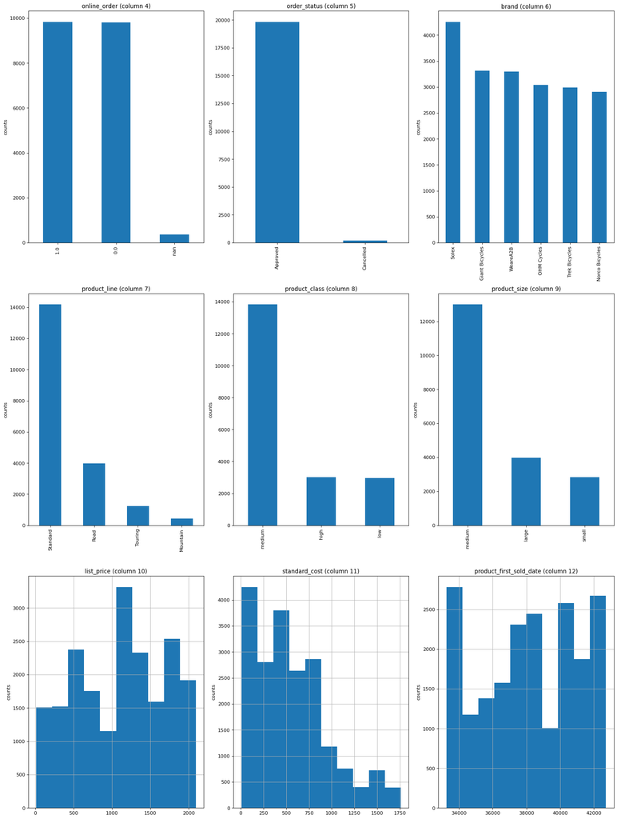

```python
plotPerColumnDistribution(Transactions, 9, 3 , [4,5,6,7,8,9,10,11,12])
```

```python
CustomerDemographic = pd.read_excel('KPMG_VI_New_raw_data_update_final.xlsx', sheet_name= 3, usecols = 'A:M', skiprows = 1)
CustomerAddress = pd.read_excel('KPMG_VI_New_raw_data_update_final.xlsx', sheet_name= 4, usecols = 'A:F', skiprows = 1)
```

```python
pd.set_option('display.max_columns', None)
CustomerDemographic.head()
```

|  | customer_id | first_name | last_name | gender | past_3_years_bike_related_purchases | DOB | job_title | job_industry_category | wealth_segment | deceased_indicator | default | owns_car | tenure |
| --- | --- | --- | --- | --- | --- | --- | --- | --- | --- | --- | --- | --- | --- |
| 0 | 1 | Laraine | Medendorp | F | 93 | 1953-10-12 | Executive Secretary | Health | Mass Customer | N | "' | Yes | 11.0 |
| 1 | 2 | Eli | Bockman | Male | 81 | 1980-12-16 | Administrative Officer | Financial Services | Mass Customer | N | <script>alert('hi')</script> | Yes | 16.0 |
| 2 | 3 | Arlin | Dearle | Male | 61 | 1954-01-20 | Recruiting Manager | Property | Mass Customer | N | 2018-02-01 00:00:00 | Yes | 15.0 |
| 3 | 4 | Talbot | NaN | Male | 33 | 1961-10-03 | NaN | IT | Mass Customer | N | () { _; } >_[$($())] { touch /tmp/blns.shellsh... | No | 7.0 |
| 4 | 5 | Sheila-kathryn | Calton | Female | 56 | 1977-05-13 | Senior Editor | NaN | Affluent Customer | N | NIL | Yes | 8.0 |

```python
CustomerDemographic.shape
```

```
(4000, 13)
```

```python
pd.set_option('display.max_columns', None)
CustomerAddress.head()
```

|  | customer_id | address | postcode | state | country | property_valuation |
| --- | --- | --- | --- | --- | --- | --- |
| 0 | 1 | 060 Morning Avenue | 2016 | New South Wales | Australia | 10 |
| 1 | 2 | 6 Meadow Vale Court | 2153 | New South Wales | Australia | 10 |
| 2 | 4 | 0 Holy Cross Court | 4211 | QLD | Australia | 9 |
| 3 | 5 | 17979 Del Mar Point | 2448 | New South Wales | Australia | 4 |
| 4 | 6 | 9 Oakridge Court | 3216 | VIC | Australia | 9 |

```python
CustomerAddress.shape
```

```
(3999, 6)
```

```python
Customers = CustomerDemographic.join(CustomerAddress.set_index('customer_id'), on='customer_id')
```

```python
Customers.head()
```

|  | customer_id | first_name | last_name | gender | past_3_years_bike_related_purchases | DOB | job_title | job_industry_category | wealth_segment | deceased_indicator | default | owns_car | tenure | address | postcode | state | country | property_valuation |
| --- | --- | --- | --- | --- | --- | --- | --- | --- | --- | --- | --- | --- | --- | --- | --- | --- | --- | --- |
| 0 | 1 | Laraine | Medendorp | F | 93 | 1953-10-12 | Executive Secretary | Health | Mass Customer | N | "' | Yes | 11.0 | 060 Morning Avenue | 2016.0 | New South Wales | Australia | 10.0 |
| 1 | 2 | Eli | Bockman | Male | 81 | 1980-12-16 | Administrative Officer | Financial Services | Mass Customer | N | <script>alert('hi')</script> | Yes | 16.0 | 6 Meadow Vale Court | 2153.0 | New South Wales | Australia | 10.0 |
| 2 | 3 | Arlin | Dearle | Male | 61 | 1954-01-20 | Recruiting Manager | Property | Mass Customer | N | 2018-02-01 00:00:00 | Yes | 15.0 | NaN | NaN | NaN | NaN | NaN |
| 3 | 4 | Talbot | NaN | Male | 33 | 1961-10-03 | NaN | IT | Mass Customer | N | () { _; } >_[$($())] { touch /tmp/blns.shellsh... | No | 7.0 | 0 Holy Cross Court | 4211.0 | QLD | Australia | 9.0 |
| 4 | 5 | Sheila-kathryn | Calton | Female | 56 | 1977-05-13 | Senior Editor | NaN | Affluent Customer | N | NIL | Yes | 8.0 | 17979 Del Mar Point | 2448.0 | New South Wales | Australia | 4.0 |

```python
Customers.drop(['default'], axis = 1, inplace=True)
Customers.info()
```

```
<class 'pandas.core.frame.DataFrame'>
RangeIndex: 4000 entries, 0 to 3999
Data columns (total 17 columns):
 #   Column                               Non-Null Count  Dtype
---  ------                               --------------  -----
 0   customer_id                          4000 non-null   int64
 1   first_name                           4000 non-null   object
 2   last_name                            3875 non-null   object
 3   gender                               4000 non-null   object
 4   past_3_years_bike_related_purchases  4000 non-null   int64
 5   DOB                                  3913 non-null   datetime64[ns]
 6   job_title                            3494 non-null   object
 7   job_industry_category                3344 non-null   object
 8   wealth_segment                       4000 non-null   object
 9   deceased_indicator                   4000 non-null   object
 10  owns_car                             4000 non-null   object
 11  tenure                               3913 non-null   float64
 12  address                              3996 non-null   object
 13  postcode                             3996 non-null   float64
 14  state                                3996 non-null   object
 15  country                              3996 non-null   object
 16  property_valuation                   3996 non-null   float64
dtypes: datetime64[ns](1), float64(3), int64(2), object(11)
memory usage: 531.4+ KB
```

```python
Customers.customer_id = Customers.customer_id.astype(str)
Customers.customer_id.dtypes
```

```
dtype('O')
```

```python
Customers.duplicated().sum()
```

```
0
```

```python
Customers['postcode'] = pd.to_numeric(Customers.postcode, errors='coerce')
Customers.postcode
```

```
0       2016.0
1       2153.0
2          NaN
3       4211.0
4       2448.0
         ...
3995    3977.0
3996    2350.0
3997    2540.0
3998    3064.0
3999    4511.0
Name: postcode, Length: 4000, dtype: float64
```

```python
Customers.postcode = Customers.postcode.apply(lambda x: "{:.0f}".
                                          format(x) if not pd.isnull(x) else x)
Customers.postcode
```

```
0       2016
1       2153
2        NaN
3       4211
4       2448
        ...
3995    3977
3996    2350
3997    2540
3998    3064
3999    4511
Name: postcode, Length: 4000, dtype: object
```

```python
Customers.gender.value_counts()
```

```
Female    2037
Male      1872
U           88
F            1
M            1
Femal        1
Name: gender, dtype: int64
```

```python
Customers.gender.replace('M', 'Male' , inplace=True)
Customers.gender.replace('F', 'Female' , inplace=True)
Customers.gender.replace('Femal', 'Female' , inplace=True)
Customers.gender.value_counts()
```

```
Female    2039
Male      1873
U           88
Name: gender, dtype: int64
```

```python
Customers.DOB.describe(datetime_is_numeric=True)
```

```
count                             3913
mean     1977-07-12 23:56:41.277792736
min                1843-12-21 00:00:00
25%                1968-01-22 00:00:00
50%                1977-07-22 00:00:00
75%                1987-02-28 00:00:00
max                2002-03-11 00:00:00
Name: DOB, dtype: object
```

```python
Customers.loc[Customers.query('DOB == DOB.min()').index , 'DOB'] = Customers.query('DOB == DOB.min()')['DOB']+ pd.DateOffset(years=100)
Customers.query('DOB == DOB.min()')['DOB']
```

```
719   1931-10-23
Name: DOB, dtype: datetime64[ns]
```

```python
Customers.deceased_indicator.value_counts()
```

```
N    3998
Y       2
Name: deceased_indicator, dtype: int64
```

```python
Customers.deceased_indicator.replace('N', False , inplace=True)
Customers.deceased_indicator.replace('Y', True , inplace=True)
Customers.deceased_indicator.value_counts()
```

```
False    3998
True        2
Name: deceased_indicator, dtype: int64
```

```python
Customers.owns_car.value_counts()
```

```
Yes    2024
No     1976
Name: owns_car, dtype: int64
```

```python
Customers.owns_car.replace('No', False , inplace=True)
Customers.owns_car.replace('Yes', True , inplace=True)
Customers.owns_car.value_counts()
```

```
True     2024
False    1976
Name: owns_car, dtype: int64
```

```python
Customers.country.value_counts()
```

```
Australia    3996
Name: country, dtype: int64
```

```python
Customers.drop(['country'], axis=1, inplace=True)
Customers.info()
```

```
<class 'pandas.core.frame.DataFrame'>
RangeIndex: 4000 entries, 0 to 3999
Data columns (total 16 columns):
 #   Column                               Non-Null Count  Dtype
---  ------                               --------------  -----
 0   customer_id                          4000 non-null   object
 1   first_name                           4000 non-null   object
 2   last_name                            3875 non-null   object
 3   gender                               4000 non-null   object
 4   past_3_years_bike_related_purchases  4000 non-null   int64
 5   DOB                                  3913 non-null   datetime64[ns]
 6   job_title                            3494 non-null   object
 7   job_industry_category                3344 non-null   object
 8   wealth_segment                       4000 non-null   object
 9   deceased_indicator                   4000 non-null   bool
 10  owns_car                             4000 non-null   bool
 11  tenure                               3913 non-null   float64
 12  address                              3996 non-null   object
 13  postcode                             3996 non-null   object
 14  state                                3996 non-null   object
 15  property_valuation                   3996 non-null   float64
dtypes: bool(2), datetime64[ns](1), float64(2), int64(1), object(10)
memory usage: 445.4+ KB
```

```python
Customers.state.value_counts()
```

```
NSW                2052
VIC                 939
QLD                 837
New South Wales      86
Victoria             82
Name: state, dtype: int64
```

```python
Customers.state.replace('New South Wales', 'NSW' , inplace=True)
Customers.state.replace('Victoria', 'VIC' , inplace=True)
Customers.state.value_counts()
```

```
NSW    2138
VIC    1021
QLD     837
Name: state, dtype: int64
```

```python
Customers.sample(5)
```

|  | customer_id | first_name | last_name | gender | past_3_years_bike_related_purchases | DOB | job_title | job_industry_category | wealth_segment | deceased_indicator | owns_car | tenure | address | postcode | state | property_valuation |
| --- | --- | --- | --- | --- | --- | --- | --- | --- | --- | --- | --- | --- | --- | --- | --- | --- |
| 1656 | 1657 | Stanwood | Troillet | Male | 11 | 1977-03-08 | Computer Systems Analyst III | Financial Services | Mass Customer | False | False | 5.0 | 4 Jay Court | 2763 | NSW | 9.0 |
| 284 | 285 | Julee | Janovsky | Female | 3 | 1977-11-19 | Community Outreach Specialist | Manufacturing | Mass Customer | False | False | 12.0 | 58 Parkside Hill | 2117 | NSW | 12.0 |
| 3962 | 3963 | Ardelle | Dasent | Female | 10 | 1954-08-22 | Software Test Engineer II | NaN | Mass Customer | False | False | 13.0 | 98 Transport Plaza | 2470 | NSW | 2.0 |
| 824 | 825 | Willis | Whyler | Male | 17 | 1975-08-15 | Computer Systems Analyst IV | NaN | Affluent Customer | False | True | 16.0 | 8640 Village Junction | 2066 | NSW | 12.0 |
| 3389 | 3390 | Fayth | Baudins | Female | 20 | 1969-01-27 | NaN | NaN | High Net Worth | False | False | 7.0 | 10097 Hooker Way | 3196 | VIC | 8.0 |

```python
Customers.shape
```

```
(4000, 16)
```

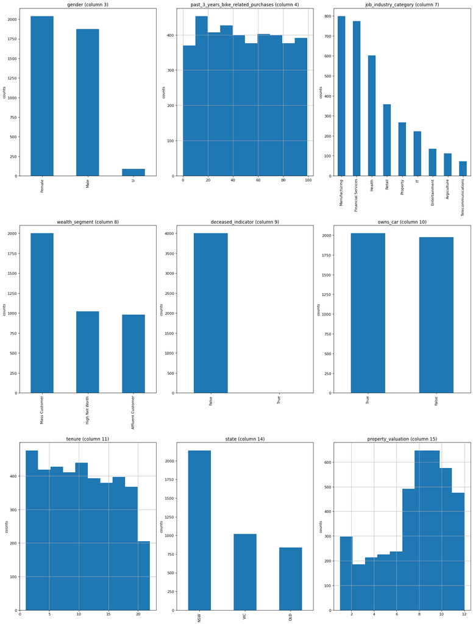

```python
plotPerColumnDistribution(Customers, 9, 3 , [3,4,7,8,9,10,11,14,15])
```

## Email

Hi there,

After having a deep look into the 3 datasets you have provided, I have made some conclusions about the data quality and I got some advice for how to improve your datasets for better results when using it for segmentation and decision making.

Here are some of the Quality issues I found in the datasets :

- Missing address values for some customers.
- Missing values in other columns.
- Missing values registed with different names like the string 'nan'.
- Erroness values (like the date of birth of one customer being 1843-12-21).
- Inconsistent values in the Default columns.
- Inaccurate different values for the same gender in the gender column ( Female = Female, Femal, F and Male = Male , M)
- Different values for Binary true and false values. (Y/N , Yes/No ). Should use True/False
- Column country contain one unique value 'Australia'. Irrelevant data should be dropped.
- Inaccurate different values for States (NSW/New South Whales , VIC/Victoria).

My advice for you is to pay attention to these mistakes as it can lead to false interpretations of the data.

Thanks